# The Effect of Source Prestige on Perceived Credibility of Health Information

- Show All Code
- Hide All Code
- View Source

PSY 120L Reproducible Analysis Report

Author

Matthew Miles

Published

June 7, 2026

## About This Report

This report outlines the steps used to prepare the data, create the study variables, generate descriptive statistics, and conduct the primary analyses and figures for this project. It is designed to provide a clear and reproducible record of the analytical process used throughout the study. Although it accompanies the manuscript-style research paper, this report focuses on documenting the workflow and statistical procedures rather than serving as the paper itself.

## Study Overview

The purpose of this study was to examine whether source prestige influences perceptions of credibility when individuals evaluate health-related information. Participants were randomly assigned to read one of two versions of the same health article that differed only in the prestige of the source. In the high-prestige condition, the article was presented as being written by a highly accomplished expert affiliated with a well-known institution, whereas in the low-prestige condition, the author was described as having fewer credentials and a less prestigious affiliation.

After reading the article, participants completed a measure of perceived source credibility. Participants also completed measures of Need for Cognition and Trust in Science and Scientists, which were examined as potential moderators of the relationship between source prestige and perceived credibility. The primary goal was to determine whether source prestige affects credibility judgments and whether this effect differs depending on individual differences in thinking style and trust in scientific information.

## Setup and Software Environment

This section loads the packages used for data preparation, scale construction, statistical modeling, estimated marginal means, and figures.

**Load Packages**

```r
library(tidyverse)  # data manipulation + plotting
library(psych)      # scale construction + reliability
library(afex)       # ANOVA models + effect sizes
library(emmeans)    # estimated marginal means + confidence intervals
```

## Data Source and Analysis Dataset

The dataset was imported from the project data folder. The imported dataset was saved as study_raw so that the original file remained unchanged throughout the report.

A smaller analysis dataset was then created for the current analyses. This dataset retained the study condition variables, demographic variables, Need for Cognition items, Trust in Science items, and Source Credibility items

### Import Dataset

```r
study_raw <- read_csv("data/prestige_bias_data.csv")
```

### Check Imported Dataset

```r
dim(study_raw)
```

```
[1] 55 52
```

```r
names(study_raw)
```

```
 [1] "StartDate"             "EndDate"               "Duration (in seconds)"
 [4] "Finished"              "RecordedDate"          "Consent"
 [7] "MC1"                   "SCSIntelligent"        "SCSTrained"
[10] "SCSHonest"             "SCSTrust"              "SCSExpert"
[13] "SCSSelf"               "SCSHonorable"          "SCSInformed"
[16] "SCSMoral"              "SCSCompetent"          "SCSEthical"
[19] "SCSsensitive"          "SCSbright"             "SCSgenuine"
[22] "SCSunderstanding"      "NFC_1"                 "NFC_2"
[25] "NFC_3"                 "NFC_4"                 "NFC_5"
[28] "NFC_6"                 "TIS_1"                 "TIS_2"
[31] "TIS_3"                 "TIS_4"                 "TIS_5"
[34] "TIS_6"                 "TIS_7"                 "TIS_8"
[37] "TIS_9"                 "TIS_10"                "TIS_11"
[40] "TIS_12"                "TIS_13"                "TIS_14"
[43] "TIS_15"                "TIS_16"                "TIS_17"
[46] "TIS_18"                "TIS_19"                "TIS_20"
[49] "TIS_21"                "gender"                "age"
[52] "condition"
```

```r
head(study_raw)
```

```
# A tibble: 6 × 52
  StartDate   EndDate Duration (in seconds…¹ Finished RecordedDate Consent   MC1
  <chr>       <chr>                    <dbl>    <dbl> <chr>          <dbl> <dbl>
1 4/30/26 18… 4/30/2…                     56        1 4/30/26 18:…       2    NA
2 4/30/26 18… 4/30/2…                     43        1 4/30/26 18:…       2    NA
3 4/30/26 18… 4/30/2…                    137        1 4/30/26 18:…       2    NA
4 5/5/26 21:… 5/5/26…                    374        1 5/5/26 21:53       2     0
5 5/6/26 13:… 5/6/26…                    536        1 5/6/26 13:16       2    NA
6 5/6/26 18:… 5/6/26…                    385        1 5/6/26 18:23       2    NA
# ℹ abbreviated name: ¹`Duration (in seconds)`
# ℹ 45 more variables: SCSIntelligent <dbl>, SCSTrained <dbl>, SCSHonest <dbl>,
#   SCSTrust <dbl>, SCSExpert <dbl>, SCSSelf <dbl>, SCSHonorable <dbl>,
#   SCSInformed <dbl>, SCSMoral <dbl>, SCSCompetent <dbl>, SCSEthical <dbl>,
#   SCSsensitive <dbl>, SCSbright <dbl>, SCSgenuine <dbl>,
#   SCSunderstanding <dbl>, NFC_1 <dbl>, NFC_2 <dbl>, NFC_3 <dbl>, NFC_4 <dbl>,
#   NFC_5 <dbl>, NFC_6 <dbl>, TIS_1 <dbl>, TIS_2 <dbl>, TIS_3 <dbl>, …
```

The import checks confirm that the dataset loaded successfully, show the number of rows and columns, and display the variable names available in the original dataset.

### Create Analysis Dataset

```r
study_vars <- c(
  "condition", "age", "gender",

  "SCSIntelligent", "SCSTrained", "SCSHonest", "SCSTrust",
  "SCSExpert", "SCSSelf", "SCSHonorable", "SCSInformed",
  "SCSMoral", "SCSCompetent", "SCSEthical", "SCSsensitive",
  "SCSbright", "SCSgenuine", "SCSunderstanding",

  "NFC_1", "NFC_2", "NFC_3", "NFC_4", "NFC_5", "NFC_6",

  "TIS_1", "TIS_2", "TIS_3", "TIS_4", "TIS_5",
  "TIS_6", "TIS_7", "TIS_8", "TIS_9", "TIS_10",
  "TIS_11", "TIS_12", "TIS_13", "TIS_14", "TIS_15",
  "TIS_16", "TIS_17", "TIS_18", "TIS_19", "TIS_20",
  "TIS_21"
)

study_data <- study_raw %>%
  select(all_of(study_vars)) %>%
  mutate(
    across(everything(), as.numeric)
  )
```

### Check Analysis Dataset

```r
length(study_vars)
```

```
[1] 45
```

```r
dim(study_data)
```

```
[1] 55 45
```

```r
names(study_data)
```

```
 [1] "condition"        "age"              "gender"           "SCSIntelligent"
 [5] "SCSTrained"       "SCSHonest"        "SCSTrust"         "SCSExpert"
 [9] "SCSSelf"          "SCSHonorable"     "SCSInformed"      "SCSMoral"
[13] "SCSCompetent"     "SCSEthical"       "SCSsensitive"     "SCSbright"
[17] "SCSgenuine"       "SCSunderstanding" "NFC_1"            "NFC_2"
[21] "NFC_3"            "NFC_4"            "NFC_5"            "NFC_6"
[25] "TIS_1"            "TIS_2"            "TIS_3"            "TIS_4"
[29] "TIS_5"            "TIS_6"            "TIS_7"            "TIS_8"
[33] "TIS_9"            "TIS_10"           "TIS_11"           "TIS_12"
[37] "TIS_13"           "TIS_14"           "TIS_15"           "TIS_16"
[41] "TIS_17"           "TIS_18"           "TIS_19"           "TIS_20"
[45] "TIS_21"
```

The analysis dataset contains the variables required for the report. The checks confirm the number of selected variables, the dimensions of the analysis dataset, and the final variable names carried forward into the preparation and analysis sections.

## Variable Preparation

This section prepares the variables used in the primary analyses. The original imported dataset was left unchanged; all prepared variables were created in the working analysis dataset, study_data.

### Prepare Participant ID and Experimental Condition

```r
study_data <- study_data %>%
  mutate(
    id = row_number(),
    condition = factor(
      condition,
      levels = c(0, 1),
      labels = c("Low Prestige", "High Prestige")
    )
  )
```

The experimental condition variable was recoded as a labeled factor with two levels: Low Prestige and High Prestige. A participant ID variable was also created so that each row in the analysis dataset had a unique identifier.

### Check Experimental Condition Coding

```r
study_data %>%
  count(condition) %>%
  knitr::kable(
    col.names = c("Condition", "n")
  )
```

| Condition | n |
| --- | --- |
| Low Prestige | 28 |
| High Prestige | 27 |

The condition check confirms the number of participants assigned to each prestige condition.

### Check Prepared Analysis Dataset

```r
dim(study_data)
```

```
[1] 55 46
```

```r
names(study_data)
```

```
 [1] "condition"        "age"              "gender"           "SCSIntelligent"
 [5] "SCSTrained"       "SCSHonest"        "SCSTrust"         "SCSExpert"
 [9] "SCSSelf"          "SCSHonorable"     "SCSInformed"      "SCSMoral"
[13] "SCSCompetent"     "SCSEthical"       "SCSsensitive"     "SCSbright"
[17] "SCSgenuine"       "SCSunderstanding" "NFC_1"            "NFC_2"
[21] "NFC_3"            "NFC_4"            "NFC_5"            "NFC_6"
[25] "TIS_1"            "TIS_2"            "TIS_3"            "TIS_4"
[29] "TIS_5"            "TIS_6"            "TIS_7"            "TIS_8"
[33] "TIS_9"            "TIS_10"           "TIS_11"           "TIS_12"
[37] "TIS_13"           "TIS_14"           "TIS_15"           "TIS_16"
[41] "TIS_17"           "TIS_18"           "TIS_19"           "TIS_20"
[45] "TIS_21"           "id"
```

The prepared analysis dataset contains the variables needed for scale construction, descriptive statistics, and primary analyses.

### Reverse-Code Scale Items

Items requiring reverse coding were transformed before scale scores were computed. Source Credibility Scale items were reverse coded by subtracting each response from 8, while Need for Cognition and Trust in Science and Scientists items were reverse coded by subtracting each response from 6. This ensured that higher scores consistently reflected higher levels of each construct.

```r
study_data <- study_data %>%
  mutate(
    SCSIntelligent_R = 8 - SCSIntelligent,
    SCSHonest_R = 8 - SCSHonest,
    SCSHonorable_R = 8 - SCSHonorable,
    SCSInformed_R = 8 - SCSInformed,
    SCSMoral_R = 8 - SCSMoral,
    SCSbright_R = 8 - SCSbright,

    NFC_3_R = 6 - NFC_3,
    NFC_4_R = 6 - NFC_4,

    TIS_1_R = 6 - TIS_1,
    TIS_2_R = 6 - TIS_2,
    TIS_3_R = 6 - TIS_3,
    TIS_4_R = 6 - TIS_4,
    TIS_6_R = 6 - TIS_6,
    TIS_8_R = 6 - TIS_8,
    TIS_13_R = 6 - TIS_13,
    TIS_17_R = 6 - TIS_17,
    TIS_18_R = 6 - TIS_18,
    TIS_19_R = 6 - TIS_19,
    TIS_20_R = 6 - TIS_20,
    TIS_21_R = 6 - TIS_21
  )
```

### Check Reverse Coding

```r
study_data %>%
  select(
    SCSIntelligent, SCSIntelligent_R,
    NFC_3, NFC_3_R,
    TIS_1, TIS_1_R
  ) %>%
  head(10) %>%
  knitr::kable()
```

| SCSIntelligent | SCSIntelligent_R | NFC_3 | NFC_3_R | TIS_1 | TIS_1_R |
| --- | --- | --- | --- | --- | --- |
| 1 | 7 | 5 | 1 | 3 | 3 |
| 4 | 4 | 5 | 1 | 3 | 3 |
| 4 | 4 | 1 | 5 | 3 | 3 |
| 4 | 4 | 2 | 4 | 4 | 2 |
| 4 | 4 | 2 | 4 | 2 | 4 |
| 2 | 6 | 1 | 5 | 2 | 4 |
| 5 | 3 | 4 | 2 | 4 | 2 |
| 5 | 3 | 3 | 3 | 2 | 4 |
| 5 | 3 | 3 | 3 | 4 | 2 |
| 2 | 6 | 2 | 4 | 3 | 3 |

### Create Scale Scores

Scale item lists were defined and used to compute Source Competence, Source Goodwill, Source Trustworthiness, Need for Cognition, and Trust in Science and Scientists scale scores.

```r
# Define Source Credibility Scale items: competence subscale
source_competence_items <- c(
  "SCSIntelligent_R", "SCSTrained", "SCSExpert",
  "SCSInformed_R", "SCSCompetent", "SCSbright_R"
)

# Define Source Credibility Scale items: caring/goodwill subscale
source_goodwill_items <- c(
  "SCSSelf", "SCSsensitive", "SCSunderstanding"
)

# Define Source Credibility Scale items: trustworthiness subscale
source_trustworthiness_items <- c(
  "SCSHonest_R", "SCSTrust", "SCSHonorable_R",
  "SCSMoral_R", "SCSgenuine"
)

# Define Need for Cognition Scale items
nfc_items <- c(
  "NFC_1", "NFC_2", "NFC_3_R",
  "NFC_4_R", "NFC_5", "NFC_6"
)

# Define Trust in Science Scale items
tis_items <- c(
  "TIS_1_R", "TIS_2_R", "TIS_3_R", "TIS_4_R",
  "TIS_5", "TIS_6_R", "TIS_7", "TIS_8_R",
  "TIS_9", "TIS_10", "TIS_11", "TIS_12",
  "TIS_13_R", "TIS_14", "TIS_15", "TIS_16",
  "TIS_17_R", "TIS_18_R", "TIS_19_R",
  "TIS_20_R", "TIS_21_R"
)

# Create scale scores
study_data <- study_data %>%
  mutate(
    source_competence_scale = rowMeans(across(all_of(source_competence_items)), na.rm = TRUE),
    source_goodwill_scale = rowMeans(across(all_of(source_goodwill_items)), na.rm = TRUE),
    source_trustworthiness_scale = rowMeans(across(all_of(source_trustworthiness_items)), na.rm = TRUE),
    nfc_scale = rowMeans(across(all_of(nfc_items)), na.rm = TRUE),
    tis_scale = rowMeans(across(all_of(tis_items)), na.rm = TRUE)
  )
```

### Check Scale Scores

```r
study_data %>%
  select(
    source_competence_scale,
    source_goodwill_scale,
    source_trustworthiness_scale,
    nfc_scale,
    tis_scale
  ) %>%
  summary()
```

```
 source_competence_scale source_goodwill_scale source_trustworthiness_scale
 Min.   :2.500           Min.   :1.667         Min.   :3.000
 1st Qu.:4.000           1st Qu.:4.000         1st Qu.:3.900
 Median :4.167           Median :4.000         Median :4.200
 Mean   :4.439           Mean   :4.442         Mean   :4.396
 3rd Qu.:5.000           3rd Qu.:5.000         3rd Qu.:5.000
 Max.   :7.000           Max.   :6.667         Max.   :7.000
   nfc_scale       tis_scale
 Min.   :1.333   Min.   :1.333
 1st Qu.:2.667   1st Qu.:3.167
 Median :3.167   Median :3.571
 Mean   :3.176   Mean   :3.561
 3rd Qu.:3.667   3rd Qu.:3.881
 Max.   :4.667   Max.   :4.524
```

```r
study_data %>%
  summarise(
    source_competence_scale_missing = mean(is.na(source_competence_scale)),
    source_goodwill_scale_missing = mean(is.na(source_goodwill_scale)),
    source_trustworthiness_scale_missing = mean(is.na(source_trustworthiness_scale)),
    nfc_scale_missing = mean(is.na(nfc_scale)),
    tis_scale_missing = mean(is.na(tis_scale))
  ) %>%
  knitr::kable()
```

| source_competence_scale_missing | source_goodwill_scale_missing | source_trustworthiness_scale_missing | nfc_scale_missing | tis_scale_missing |
| --- | --- | --- | --- | --- |
| 0 | 0 | 0 | 0 | 0 |

The scale-score checks confirm that the computed scale scores fall within the expected response range and show whether any scale scores are missing.

```r
# Compute median Need for Cognition score
nfc_median <- median(study_data$nfc_scale, na.rm = TRUE)

# Compute median Trust in Science score
tis_median <- median(study_data$tis_scale, na.rm = TRUE)

# Create low/high median split groups
study_data <- study_data %>%
  mutate(
    nfc_msplit = if_else(nfc_scale <= nfc_median, "Low", "High"),
    nfc_msplit = factor(nfc_msplit, levels = c("Low", "High")),

    tis_msplit = if_else(tis_scale <= tis_median, "Low", "High"),
    tis_msplit = factor(tis_msplit, levels = c("Low", "High"))
  )

# Print medians
nfc_median
```

```
[1] 3.166667
```

```r
tis_median
```

```
[1] 3.571429
```

```r
# Check group sizes
study_data %>%
  count(nfc_msplit) %>%
  knitr::kable()
```

| nfc_msplit | n |
| --- | --- |
| Low | 30 |
| High | 25 |

```r
study_data %>%
  count(tis_msplit) %>%
  knitr::kable()
```

| tis_msplit | n |
| --- | --- |
| Low | 28 |
| High | 27 |

### Check Scale Reliability

Internal consistency was estimated for the Source Competence, Source Goodwill, Source Trustworthiness, Need for Cognition, and Trust in Science and Scientists scales before the scale scores were used in the primary analyses.

```r
# Create item-only data frames for each multi-item rating scale
source_competence_item_df <- study_data %>%
  select(all_of(source_competence_items))

source_goodwill_item_df <- study_data %>%
  select(all_of(source_goodwill_items))

source_trustworthiness_item_df <- study_data %>%
  select(all_of(source_trustworthiness_items))

nfc_item_df <- study_data %>%
  select(all_of(nfc_items))

tis_item_df <- study_data %>%
  select(all_of(tis_items))

# Compute internal consistency estimates
source_competence_alpha <- psych::alpha(source_competence_item_df)
source_competence_omega <- psych::omega(source_competence_item_df, plot = FALSE)

source_goodwill_alpha <- psych::alpha(source_goodwill_item_df)
source_goodwill_omega <- psych::omega(source_goodwill_item_df, plot = FALSE)

source_trustworthiness_alpha <- psych::alpha(source_trustworthiness_item_df)
source_trustworthiness_omega <- psych::omega(source_trustworthiness_item_df, plot = FALSE)

nfc_alpha <- psych::alpha(nfc_item_df)
nfc_omega <- psych::omega(nfc_item_df, plot = FALSE)

tis_alpha <- psych::alpha(tis_item_df)
tis_omega <- psych::omega(tis_item_df, plot = FALSE)

# Print only alpha and omega coefficients
tibble(
  scale = c(
    "Source Credibility: Competence",
    "Source Credibility: Caring/Goodwill",
    "Source Credibility: Trustworthiness",
    "Need for Cognition",
    "Trust in Science"
  ),
  alpha = c(
    source_competence_alpha$total$raw_alpha,
    source_goodwill_alpha$total$raw_alpha,
    source_trustworthiness_alpha$total$raw_alpha,
    nfc_alpha$total$raw_alpha,
    tis_alpha$total$raw_alpha
  ),
  omega = c(
    source_competence_omega$omega.tot,
    source_goodwill_omega$omega.tot,
    source_trustworthiness_omega$omega.tot,
    nfc_omega$omega.tot,
    tis_omega$omega.tot
  )
) %>%
  knitr::kable(digits = 2)
```

| scale | alpha | omega |
| --- | --- | --- |
| Source Credibility: Competence | 0.67 | 0.88 |
| Source Credibility: Caring/Goodwill | 0.53 | 0.58 |
| Source Credibility: Trustworthiness | 0.55 | 0.82 |
| Need for Cognition | 0.76 | 0.89 |
| Trust in Science | 0.92 | 0.94 |

The reliability table reports alpha and omega for each scale used in the analysis.

## Descriptive Statistics

This section summarizes the scale scores and sample composition before the primary hypothesis tests.

### Scale Score Descriptives

```r
study_data %>%
  select(
    source_competence_scale,
    source_goodwill_scale,
    source_trustworthiness_scale,
    nfc_scale,
    tis_scale
  ) %>%
  psych::describe() %>%
  knitr::kable(digits = 2)
```

|  | vars | n | mean | sd | median | trimmed | mad | min | max | range | skew | kurtosis | se |
| --- | --- | --- | --- | --- | --- | --- | --- | --- | --- | --- | --- | --- | --- |
| source_competence_scale | 1 | 55 | 4.44 | 0.88 | 4.17 | 4.44 | 0.74 | 2.50 | 7.00 | 4.50 | 0.30 | 0.05 | 0.12 |
| source_goodwill_scale | 2 | 55 | 4.44 | 0.88 | 4.00 | 4.41 | 0.49 | 1.67 | 6.67 | 5.00 | 0.16 | 0.91 | 0.12 |
| source_trustworthiness_scale | 3 | 55 | 4.40 | 0.81 | 4.20 | 4.35 | 0.89 | 3.00 | 7.00 | 4.00 | 0.74 | 0.40 | 0.11 |
| nfc_scale | 4 | 55 | 3.18 | 0.74 | 3.17 | 3.19 | 0.74 | 1.33 | 4.67 | 3.33 | -0.18 | -0.11 | 0.10 |
| tis_scale | 5 | 55 | 3.56 | 0.54 | 3.57 | 3.57 | 0.49 | 1.33 | 4.52 | 3.19 | -0.98 | 3.49 | 0.07 |

The table reports descriptive statistics for the Source Competence, Source Goodwill, Source Trustworthiness, Need for Cognition, and Trust in Science and Scientists scale scores used in the primary analyses.

### Sample Composition by Age and Gender

```r
# Summarize age group
study_data %>%
  mutate(
    age_group = factor(
      age,
      levels = c(1, 2, 3, 4, 5, 6),
      labels = c(
        "Under 18",
        "18-24",
        "25-34",
        "35-44",
        "45-54",
        "55 or older"
      )
    )
  ) %>%
  count(age_group) %>%
  mutate(percent = round(100 * n / sum(n), 1)) %>%
  knitr::kable(
    col.names = c("Age Group", "n", "Percent"),
    caption = "Sample Composition by Age Group"
  )
```

Sample Composition by Age Group

| Age Group | n | Percent |
| --- | --- | --- |
| 18-24 | 45 | 81.8 |
| 25-34 | 4 | 7.3 |
| 35-44 | 1 | 1.8 |
| 45-54 | 1 | 1.8 |
| 55 or older | 4 | 7.3 |

```r
# Summarize gender
study_data %>%
  mutate(
    gender_group = factor(
      gender,
      levels = c(1, 2, 3, 4),
      labels = c(
        "Male",
        "Female",
        "Non-binary / Third gender",
        "Prefer not to say"
      )
    )
  ) %>%
  count(gender_group) %>%
  mutate(percent = round(100 * n / sum(n), 1)) %>%
  knitr::kable(
    col.names = c("Gender", "n", "Percent"),
    caption = "Sample Composition by Gender"
  )
```

Sample Composition by Gender

| Gender | n | Percent |
| --- | --- | --- |
| Male | 12 | 21.8 |
| Female | 40 | 72.7 |
| Prefer not to say | 3 | 5.5 |

The tables report the number and percentage of participants in each age and gender category.

## Correlations Among the DVs

Pearson correlations were computed among the Source Competence, Source Goodwill, Source Trustworthiness, Need for Cognition, and Trust in Science and Scientists scale scores to examine the relationships among the primary study variables before conducting the main analyses.

```r
# Correlations for the main continuous study variables
psych::corr.test(
  study_data %>%
    select(
      source_competence_scale,
      source_goodwill_scale,
      source_trustworthiness_scale,
      nfc_scale,
      tis_scale
    )
)
```

```
Call:psych::corr.test(x = study_data %>% select(source_competence_scale,
    source_goodwill_scale, source_trustworthiness_scale, nfc_scale,
    tis_scale))
Correlation matrix
                             source_competence_scale source_goodwill_scale
source_competence_scale                         1.00                  0.40
source_goodwill_scale                           0.40                  1.00
source_trustworthiness_scale                    0.71                  0.36
nfc_scale                                       0.04                  0.05
tis_scale                                       0.25                  0.18
                             source_trustworthiness_scale nfc_scale tis_scale
source_competence_scale                              0.71      0.04      0.25
source_goodwill_scale                                0.36      0.05      0.18
source_trustworthiness_scale                         1.00      0.11      0.25
nfc_scale                                            0.11      1.00      0.14
tis_scale                                            0.25      0.14      1.00
Sample Size
[1] 55
Probability values (Entries above the diagonal are adjusted for multiple tests.)
                             source_competence_scale source_goodwill_scale
source_competence_scale                         0.00                  0.02
source_goodwill_scale                           0.00                  0.00
source_trustworthiness_scale                    0.00                  0.01
nfc_scale                                       0.75                  0.71
tis_scale                                       0.06                  0.19
                             source_trustworthiness_scale nfc_scale tis_scale
source_competence_scale                              0.00      1.00      0.44
source_goodwill_scale                                0.06      1.00      0.97
source_trustworthiness_scale                         0.00      1.00      0.44
nfc_scale                                            0.42      0.00      1.00
tis_scale                                            0.07      0.31      0.00

 To see confidence intervals of the correlations, print with the short=FALSE option
```

## Primary Analyses

This section reports the primary analyses used to examine whether Source Prestige, Need for Cognition (NFC), and Trust in Science and Scientists (TIS) influenced participants’ perceptions of source credibility.

A series of 2 × 2 between-subjects ANOVAs were estimated. Three models examined the effects of Source Prestige and Need for Cognition group on Source Competence, Source Goodwill, and Source Trustworthiness ratings, and three additional models examined the effects of Source Prestige and Trust in Science and Scientists group on the same dependent variables. In all models, Source Prestige served as the manipulated independent variable, whereas Need for Cognition and Trust in Science and Scientists were treated as categorical moderators.

### **Source Competence Model with NFC**

A 2 × 2 between-subjects ANOVA was conducted to examine the effects of Source Prestige (High vs. Low) and Need for Cognition group (High vs. Low) on Source Competence ratings.

```r
a1_competence <- afex::aov_ez(
  id = "id",
  dv = "source_competence_scale",
  between = c("condition", "nfc_msplit"),
  data = study_data
)

# Print the ANOVA table
a1_competence
```

```
Anova Table (Type 3 tests)

Response: source_competence_scale
                Effect    df  MSE    F   ges p.value
1            condition 1, 51 0.82 0.39  .008    .533
2           nfc_msplit 1, 51 0.82 0.00 <.001    .986
3 condition:nfc_msplit 1, 51 0.82 0.12  .002    .733
---
Signif. codes:  0 '***' 0.001 '**' 0.01 '*' 0.05 '+' 0.1 ' ' 1
```

The ANOVA revealed no significant main effect of Source Prestige, no significant main effect of Need for Cognition, and no significant interaction between Source Prestige and Need for Cognition on Source Competence ratings (all ps > .05). These results suggest that neither source prestige nor need for cognition influenced perceived source competence in this sample.

### Estimated Means for Source Competence with NFC

```r
emmeans(a1_competence, ~ condition)
```

```
 condition     emmean    SE df lower.CL upper.CL
 Low Prestige    4.52 0.175 51     4.17     4.87
 High Prestige   4.37 0.174 51     4.02     4.71

Results are averaged over the levels of: nfc_msplit
Confidence level used: 0.95
```

```r
emmeans(a1_competence, ~ nfc_msplit)
```

```
 nfc_msplit emmean    SE df lower.CL upper.CL
 Low          4.45 0.166 51     4.11     4.78
 High         4.44 0.182 51     4.08     4.81

Results are averaged over the levels of: condition
Confidence level used: 0.95
```

```r
emmeans(a1_competence, ~ condition * nfc_msplit)
```

```
 condition     nfc_msplit emmean    SE df lower.CL upper.CL
 Low Prestige  Low          4.48 0.219 51     4.04     4.92
 High Prestige Low          4.41 0.250 51     3.91     4.91
 Low Prestige  High         4.56 0.272 51     4.01     5.11
 High Prestige High         4.32 0.241 51     3.84     4.81

Confidence level used: 0.95
```

The estimated marginal means indicate very similar Source Competence ratings across both Source Prestige and Need for Cognition groups. Participants in the Low Prestige condition reported slightly higher competence ratings than those in the High Prestige condition, and competence ratings were nearly identical for participants with low and high Need for Cognition. Consistent with the ANOVA results, these estimated means provide little evidence of a meaningful main effect or interaction.

### **Source Competence** Model with TIS

A 2 × 2 between-subjects ANOVA was conducted to examine the effects of Source Prestige (High vs. Low) and Trust in Science and Scientists group (High vs. Low) on Source Competence ratings.

```r
# 2x2 between-subjects ANOVA predicting source competence scores
# DV: source_competence_scale
# Factors: condition and Trust in Science group
a2_competence <- afex::aov_ez(
  id = "id",
  dv = "source_competence_scale",
  between = c("condition", "tis_msplit"),
  data = study_data
)

# Print the ANOVA table
a2_competence
```

```
Anova Table (Type 3 tests)

Response: source_competence_scale
                Effect    df  MSE    F  ges p.value
1            condition 1, 51 0.79 0.30 .006    .584
2           tis_msplit 1, 51 0.79 0.86 .017    .357
3 condition:tis_msplit 1, 51 0.79 1.12 .021    .296
---
Signif. codes:  0 '***' 0.001 '**' 0.01 '*' 0.05 '+' 0.1 ' ' 1
```

The ANOVA revealed no significant main effect of Source Prestige, no significant main effect of Trust in Science and Scientists, and no significant interaction between Source Prestige and Trust in Science and Scientists on Source Competence ratings (all ps > .05). These findings suggest that neither source prestige nor trust in science influenced perceptions of source competence in this sample.

### Estimated Means for Source Competence with TIS

```r
emmeans(a2_competence, ~ condition)
```

```
 condition     emmean    SE df lower.CL upper.CL
 Low Prestige    4.49 0.168 51     4.16     4.83
 High Prestige   4.36 0.172 51     4.02     4.71

Results are averaged over the levels of: tis_msplit
Confidence level used: 0.95
```

```r
emmeans(a2_competence, ~ tis_msplit)
```

```
 tis_msplit emmean    SE df lower.CL upper.CL
 Low          4.32 0.168 51     3.98     4.65
 High         4.54 0.172 51     4.20     4.88

Results are averaged over the levels of: condition
Confidence level used: 0.95
```

```r
emmeans(a2_competence, ~ condition * tis_msplit)
```

```
 condition     tis_msplit emmean    SE df lower.CL upper.CL
 Low Prestige  Low          4.26 0.246 51     3.76     4.75
 High Prestige Low          4.38 0.229 51     3.92     4.84
 Low Prestige  High         4.73 0.229 51     4.27     5.19
 High Prestige High         4.35 0.256 51     3.83     4.86

Confidence level used: 0.95
```

The estimated marginal means indicate that Source Competence ratings were similar across both Source Prestige and Trust in Science and Scientists groups. Although participants with higher Trust in Science reported slightly higher competence ratings than those with lower Trust in Science, the differences across conditions were small and consistent with the ANOVA results, which showed no significant main effects or interaction.

### **Source Goodwill** Model with NFC

A 2 × 2 between-subjects ANOVA was conducted to examine the effects of Source Prestige (High vs. Low) and Need for Cognition group (High vs. Low) on Source Goodwill ratings.

```r
# 2x2 between-subjects ANOVA predicting source goodwill scores
# DV: source_goodwill_scale
# Factors: condition and Need for Cognition group
a3_goodwill <- afex::aov_ez(
  id = "id",
  dv = "source_goodwill_scale",
  between = c("condition", "nfc_msplit"),
  data = study_data
)

# Print the ANOVA table
a3_goodwill
```

```
Anova Table (Type 3 tests)

Response: source_goodwill_scale
                Effect    df  MSE    F   ges p.value
1            condition 1, 51 0.79 0.01 <.001    .930
2           nfc_msplit 1, 51 0.79 0.53  .010    .471
3 condition:nfc_msplit 1, 51 0.79 0.81  .016    .372
---
Signif. codes:  0 '***' 0.001 '**' 0.01 '*' 0.05 '+' 0.1 ' ' 1
```

The ANOVA revealed no significant main effect of Source Prestige, no significant main effect of Need for Cognition, and no significant interaction between Source Prestige and Need for Cognition on Source Goodwill ratings (all ps > .05). These findings indicate that neither source prestige nor need for cognition significantly influenced perceptions of source goodwill in this sample.

### Estimated Means for Source Goodwill with NFC

```r
emmeans(a3_goodwill, ~ condition)
```

```
 condition     emmean    SE df lower.CL upper.CL
 Low Prestige    4.41 0.172 51     4.06     4.76
 High Prestige   4.43 0.172 51     4.09     4.78

Results are averaged over the levels of: nfc_msplit
Confidence level used: 0.95
```

```r
emmeans(a3_goodwill, ~ nfc_msplit)
```

```
 nfc_msplit emmean    SE df lower.CL upper.CL
 Low          4.51 0.164 51     4.18     4.84
 High         4.33 0.180 51     3.97     4.69

Results are averaged over the levels of: condition
Confidence level used: 0.95
```

```r
emmeans(a3_goodwill, ~ condition * nfc_msplit)
```

```
 condition     nfc_msplit emmean    SE df lower.CL upper.CL
 Low Prestige  Low          4.61 0.216 51     4.17     5.04
 High Prestige Low          4.41 0.247 51     3.91     4.91
 Low Prestige  High         4.21 0.269 51     3.67     4.75
 High Prestige High         4.45 0.238 51     3.97     4.93

Confidence level used: 0.95
```

The estimated marginal means indicate that Source Goodwill ratings were very similar across Source Prestige and Need for Cognition groups. Although participants with low Need for Cognition reported slightly higher goodwill ratings than those with high Need for Cognition, the differences across groups were small. Consistent with the ANOVA results, the estimated means provide little evidence of meaningful main effects or an interaction between Source Prestige and Need for Cognition.

### **Source Goodwill** Model with TIS

A 2 × 2 between-subjects ANOVA was conducted to examine the effects of Source Prestige (High vs. Low) and Trust in Science and Scientists group (High vs. Low) on Source Goodwill ratings.

```r
# 2x2 between-subjects ANOVA predicting source goodwill scores
# DV: source_goodwill_scale
# Factors: condition and Trust in Science group
a4_goodwill <- afex::aov_ez(
  id = "id",
  dv = "source_goodwill_scale",
  between = c("condition", "tis_msplit"),
  data = study_data
)

# Print the ANOVA table
a4_goodwill
```

```
Anova Table (Type 3 tests)

Response: source_goodwill_scale
                Effect    df  MSE    F   ges p.value
1            condition 1, 51 0.81 0.00 <.001    .963
2           tis_msplit 1, 51 0.81 0.10  .002    .752
3 condition:tis_msplit 1, 51 0.81 0.15  .003    .700
---
Signif. codes:  0 '***' 0.001 '**' 0.01 '*' 0.05 '+' 0.1 ' ' 1
```

The ANOVA revealed no significant main effect of Source Prestige, no significant main effect of Trust in Science and Scientists, and no significant interaction between Source Prestige and Trust in Science and Scientists on Source Goodwill ratings (all ps > .05). These findings indicate that neither source prestige nor trust in science significantly influenced perceptions of source goodwill in this sample.

### Estimated Means for Source Goodwill with TIS

```r
emmeans(a4_goodwill, ~ condition)
```

```
 condition     emmean    SE df lower.CL upper.CL
 Low Prestige    4.45 0.171 51     4.11     4.80
 High Prestige   4.44 0.174 51     4.09     4.79

Results are averaged over the levels of: tis_msplit
Confidence level used: 0.95
```

```r
emmeans(a4_goodwill, ~ tis_msplit)
```

```
 tis_msplit emmean    SE df lower.CL upper.CL
 Low          4.41 0.171 51     4.07     4.75
 High         4.49 0.174 51     4.14     4.84

Results are averaged over the levels of: condition
Confidence level used: 0.95
```

```r
emmeans(a4_goodwill, ~ condition * tis_msplit)
```

```
 condition     tis_msplit emmean    SE df lower.CL upper.CL
 Low Prestige  Low          4.46 0.250 51     3.96     4.96
 High Prestige Low          4.36 0.233 51     3.89     4.82
 Low Prestige  High         4.44 0.233 51     3.98     4.91
 High Prestige High         4.53 0.260 51     4.01     5.05

Confidence level used: 0.95
```

The estimated marginal means indicate that Source Goodwill ratings were similar across Source Prestige and Trust in Science and Scientists groups. Overall, the estimated means are consistent with the ANOVA results, showing no meaningful main effects or interaction.

### **Source Trustworthiness** Model with NFC

A 2 × 2 between-subjects ANOVA was conducted to examine the effects of Source Prestige (High vs. Low) and Need for Cognition group (High vs. Low) on Source Trustworthiness ratings.

```r
# Between-subjects ANOVA predicting source trustworthiness scores
# DV: source_trustworthiness_scale
# Factors: condition and Need for Cognition group
a5_trustworthiness <- afex::aov_ez(
  id = "id",
  dv = "source_trustworthiness_scale",
  between = c("condition", "nfc_msplit"),
  data = study_data
)

# Print the ANOVA table
a5_trustworthiness
```

```
Anova Table (Type 3 tests)

Response: source_trustworthiness_scale
                Effect    df  MSE    F  ges p.value
1            condition 1, 51 0.67 0.95 .018    .335
2           nfc_msplit 1, 51 0.67 0.17 .003    .683
3 condition:nfc_msplit 1, 51 0.67 0.26 .005    .613
---
Signif. codes:  0 '***' 0.001 '**' 0.01 '*' 0.05 '+' 0.1 ' ' 1
```

The ANOVA revealed no significant main effect of Source Prestige, no significant main effect of Need for Cognition, and no significant interaction between Source Prestige and Need for Cognition on Source Trustworthiness ratings (all ps > .05). These findings suggest that neither source prestige nor need for cognition significantly influenced perceptions of source trustworthiness in this sample.

### Estimated Means for Source Trustworthiness with NFC

```r
emmeans(a5_trustworthiness, ~ condition)
```

```
 condition     emmean    SE df lower.CL upper.CL
 Low Prestige    4.51 0.159 51     4.20     4.83
 High Prestige   4.30 0.158 51     3.98     4.61

Results are averaged over the levels of: nfc_msplit
Confidence level used: 0.95
```

```r
emmeans(a5_trustworthiness, ~ nfc_msplit)
```

```
 nfc_msplit emmean    SE df lower.CL upper.CL
 Low          4.36 0.151 51     4.06     4.66
 High         4.45 0.166 51     4.12     4.78

Results are averaged over the levels of: condition
Confidence level used: 0.95
```

```r
emmeans(a5_trustworthiness, ~ condition * nfc_msplit)
```

```
 condition     nfc_msplit emmean    SE df lower.CL upper.CL
 Low Prestige  Low          4.41 0.199 51     4.01     4.81
 High Prestige Low          4.31 0.228 51     3.85     4.77
 Low Prestige  High         4.62 0.248 51     4.12     5.12
 High Prestige High         4.29 0.220 51     3.84     4.73

Confidence level used: 0.95
```

The estimated marginal means indicate that Source Trustworthiness ratings were similar across Source Prestige and Need for Cognition groups. Overall, the estimated means are consistent with the ANOVA results, showing no meaningful main effects or interaction.

### **Source Trustworthiness** Model with TI

A 2 × 2 between-subjects ANOVA was conducted to examine the effects of Source Prestige (High vs. Low) and Trust in Science and Scientists group (High vs. Low) on Source Trustworthiness ratings.

```r
# Between-subjects ANOVA predicting source trustworthiness scores
# DV: source_trustworthiness_scale
# Factors: condition and Trust in Science group
a6_trustworthiness <- afex::aov_ez(
  id = "id",
  dv = "source_trustworthiness_scale",
  between = c("condition", "tis_msplit"),
  data = study_data
)

# Print the ANOVA table
a6_trustworthiness
```

```
Anova Table (Type 3 tests)

Response: source_trustworthiness_scale
                Effect    df  MSE    F  ges p.value
1            condition 1, 51 0.66 0.62 .012    .435
2           tis_msplit 1, 51 0.66 1.47 .028    .231
3 condition:tis_msplit 1, 51 0.66 0.05 .001    .821
---
Signif. codes:  0 '***' 0.001 '**' 0.01 '*' 0.05 '+' 0.1 ' ' 1
```

The ANOVA revealed no significant main effect of Source Prestige, no significant main effect of Trust in Science and Scientists, and no significant interaction between Source Prestige and Trust in Science and Scientists on Source Trustworthiness ratings (all ps > .05). These findings suggest that neither source prestige nor trust in science significantly influenced perceptions of source trustworthiness in this sample.

### Estimated Means for Source Trustworthiness with TIS

```r
emmeans(a6_trustworthiness, ~ condition)
```

```
 condition     emmean    SE df lower.CL upper.CL
 Low Prestige    4.48 0.154 51     4.17     4.79
 High Prestige   4.31 0.157 51     3.99     4.62

Results are averaged over the levels of: tis_msplit
Confidence level used: 0.95
```

```r
emmeans(a6_trustworthiness, ~ tis_msplit)
```

```
 tis_msplit emmean    SE df lower.CL upper.CL
 Low          4.26 0.154 51     3.95     4.57
 High         4.53 0.157 51     4.21     4.84

Results are averaged over the levels of: condition
Confidence level used: 0.95
```

```r
emmeans(a6_trustworthiness, ~ condition * tis_msplit)
```

```
 condition     tis_msplit emmean    SE df lower.CL upper.CL
 Low Prestige  Low          4.32 0.225 51     3.87     4.78
 High Prestige Low          4.20 0.210 51     3.78     4.62
 Low Prestige  High         4.64 0.210 51     4.22     5.06
 High Prestige High         4.42 0.235 51     3.95     4.89

Confidence level used: 0.95
```

The estimated marginal means indicate that Source Trustworthiness ratings were similar across Source Prestige and Trust in Science and Scientists groups. Overall, the estimated means are consistent with the ANOVA results, showing no meaningful main effects or interaction.

## Figures

This section creates the figures used to visualize the primary 2 × 2 ANOVA results. The figures are based on the estimated cell means from the ANOVA models.

### Source Competence x NFC Interaction Plot

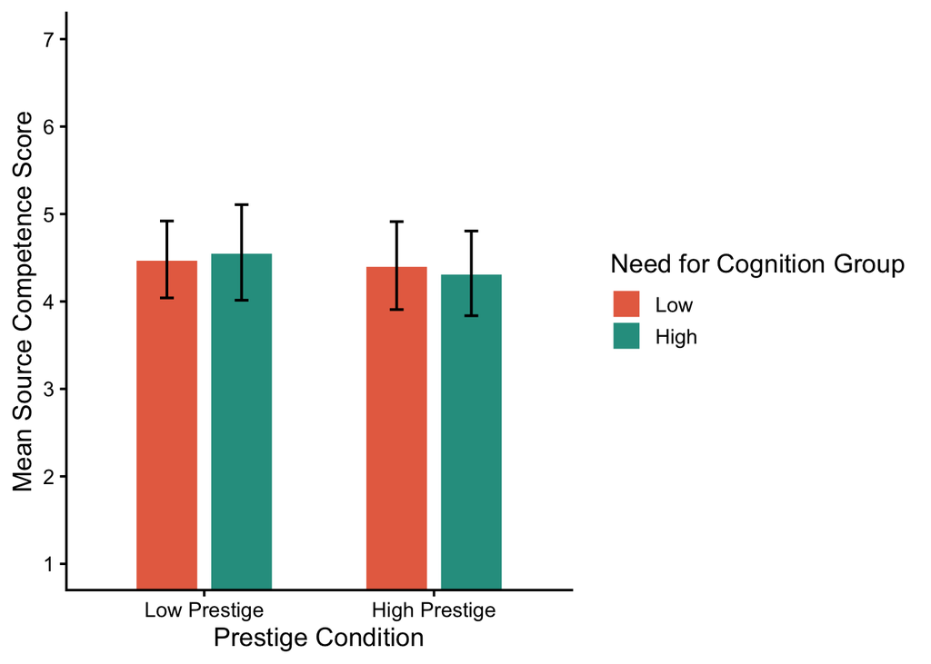

```r
p_source_competence_nfc_bar <- ggplot(
  as.data.frame(emmeans(a1_competence, ~ condition * nfc_msplit)),
  aes(
    x = condition,
    y = emmean,
    fill = nfc_msplit
  )
) +
  geom_col(
    position = position_dodge(width = 0.65),
    width = 0.55,
    color = "white"
  ) +
  geom_errorbar(
    aes(
      ymin = lower.CL,
      ymax = upper.CL
    ),
    position = position_dodge(width = 0.65),
    width = 0.12,
    linewidth = 0.7
  ) +
  labs(
    x = "Prestige Condition",
    y = "Mean Source Competence Score",
    fill = "Need for Cognition Group"
  ) +
  scale_fill_manual(
    values = c(
      "Low" = "#E76F51", # YOU CAN CHANGE THESE HEX VALUES TO MATCH YOUR POSTER!
      "High" = "#2A9D8F"
    )
  ) +
  scale_y_continuous(
    breaks = seq(1, 7, 1)
  ) +
  coord_cartesian(
    ylim = c(1, 7)
  ) +
  theme_classic(
    base_size = 14
  )

p_source_competence_nfc_bar
```

The figure shows estimated Source Competence scores by Source Prestige condition and Need for Cognition group. Error bars represent 95% confidence intervals.

### Source Competence × Trust in Science Interaction Plot

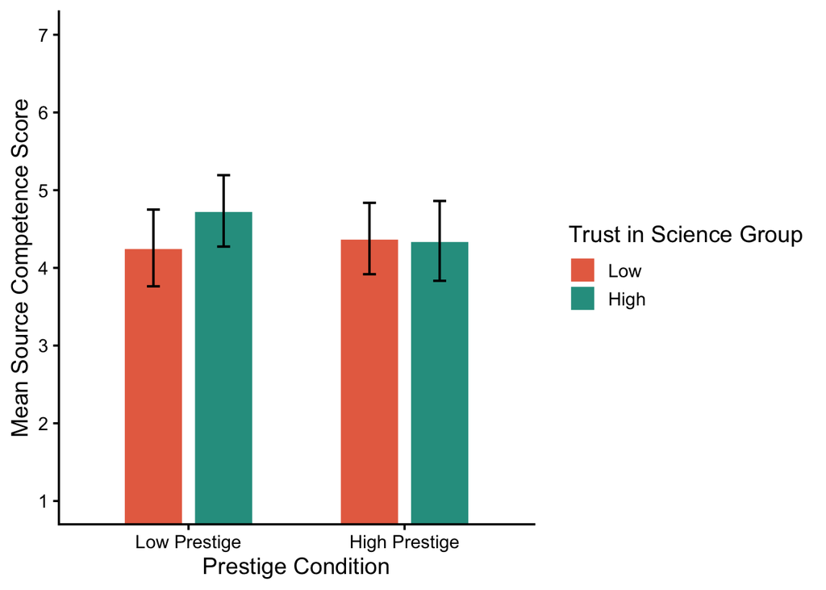

```r
p_source_competence_tis_bar <- ggplot(
  as.data.frame(emmeans(a2_competence, ~ condition * tis_msplit)),
  aes(
    x = condition,
    y = emmean,
    fill = tis_msplit
  )
) +
  geom_col(
    position = position_dodge(width = 0.65),
    width = 0.55,
    color = "white"
  ) +
  geom_errorbar(
    aes(
      ymin = lower.CL,
      ymax = upper.CL
    ),
    position = position_dodge(width = 0.65),
    width = 0.12,
    linewidth = 0.7
  ) +
  labs(
    x = "Prestige Condition",
    y = "Mean Source Competence Score",
    fill = "Trust in Science Group"
  ) +
  scale_fill_manual(
    values = c(
      "Low" = "#E76F51",
      "High" = "#2A9D8F"
    )
  ) +
  scale_y_continuous(
    breaks = seq(1, 7, 1)
  ) +
  coord_cartesian(
    ylim = c(1, 7)
  ) +
  theme_classic(
    base_size = 14
  )

p_source_competence_tis_bar
```

The figure shows estimated Source Competence scores by Source Prestige condition and Trust in Science and Scientists group. Error bars represent 95% confidence intervals.

### Source Goodwill × Need for Cognition Interaction Plot

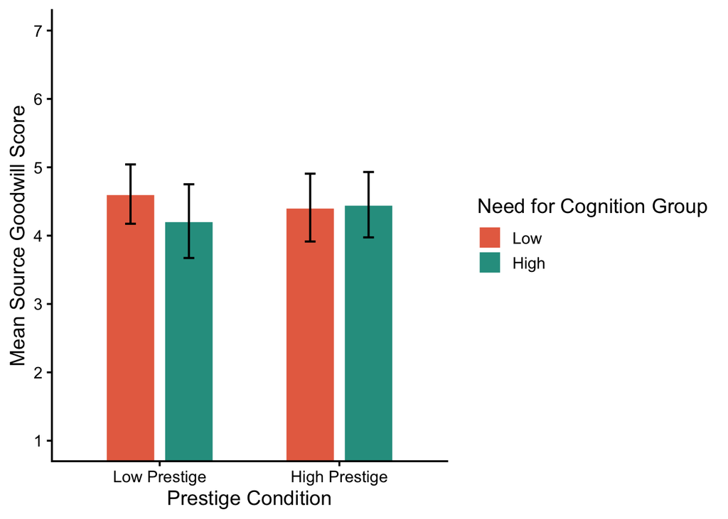

```r
p_source_goodwill_nfc_bar <- ggplot(
  as.data.frame(emmeans(a3_goodwill, ~ condition * nfc_msplit)),
  aes(
    x = condition,
    y = emmean,
    fill = nfc_msplit
  )
) +
  geom_col(
    position = position_dodge(width = 0.65),
    width = 0.55,
    color = "white"
  ) +
  geom_errorbar(
    aes(
      ymin = lower.CL,
      ymax = upper.CL
    ),
    position = position_dodge(width = 0.65),
    width = 0.12,
    linewidth = 0.7
  ) +
  labs(
    x = "Prestige Condition",
    y = "Mean Source Goodwill Score",
    fill = "Need for Cognition Group"
  ) +
  scale_fill_manual(
    values = c(
      "Low" = "#E76F51",
      "High" = "#2A9D8F"
    )
  ) +
  scale_y_continuous(
    breaks = seq(1, 7, 1)
  ) +
  coord_cartesian(
    ylim = c(1, 7)
  ) +
  theme_classic(
    base_size = 14
  )

p_source_goodwill_nfc_bar
```

The figure shows estimated Source Goodwill scores by Source Prestige condition and Need for Cognition group. Error bars represent 95% confidence intervals.

### Source Goodwill × Trust in Science Interaction Plot

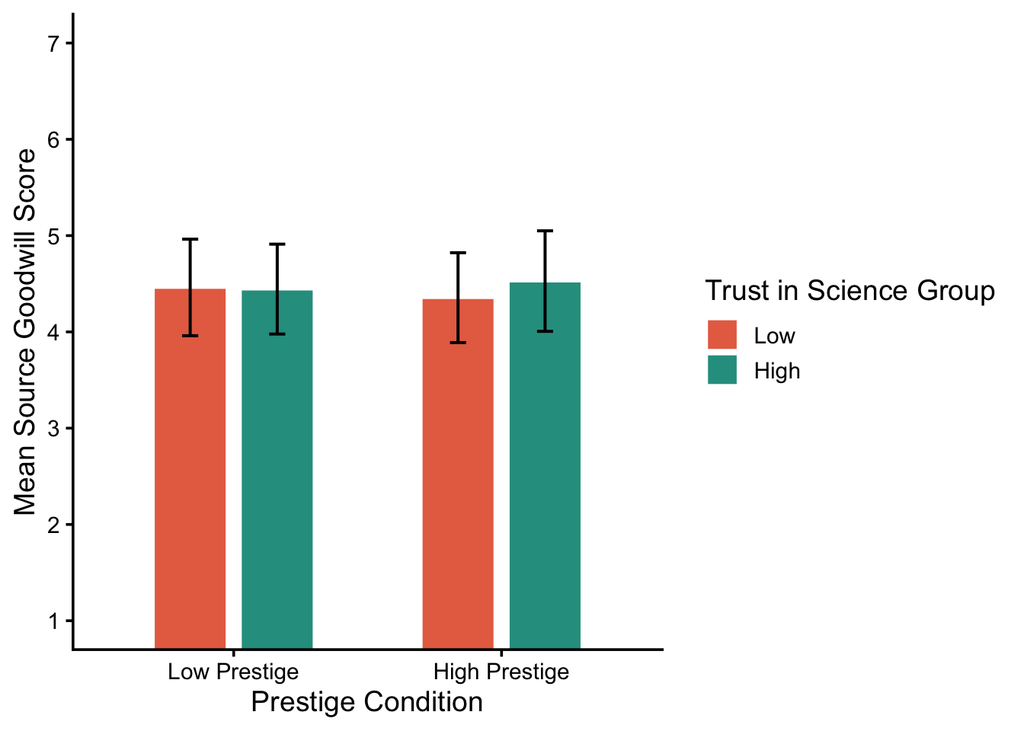

```r
p_source_goodwill_tis_bar <- ggplot(
  as.data.frame(emmeans(a4_goodwill, ~ condition * tis_msplit)),
  aes(
    x = condition,
    y = emmean,
    fill = tis_msplit
  )
) +
  geom_col(
    position = position_dodge(width = 0.65),
    width = 0.55,
    color = "white"
  ) +
  geom_errorbar(
    aes(
      ymin = lower.CL,
      ymax = upper.CL
    ),
    position = position_dodge(width = 0.65),
    width = 0.12,
    linewidth = 0.7
  ) +
  labs(
    x = "Prestige Condition",
    y = "Mean Source Goodwill Score",
    fill = "Trust in Science Group"
  ) +
  scale_fill_manual(
    values = c(
      "Low" = "#E76F51",
      "High" = "#2A9D8F"
    )
  ) +
  scale_y_continuous(
    breaks = seq(1, 7, 1)
  ) +
  coord_cartesian(
    ylim = c(1, 7)
  ) +
  theme_classic(
    base_size = 14
  )

p_source_goodwill_tis_bar
```

The figure shows estimated Source Goodwill scores by Source Prestige condition and Trust in Science and Scientists group. Error bars represent 95% confidence intervals.

### Source Trustworthiness × Need for Cognition Interaction Plot

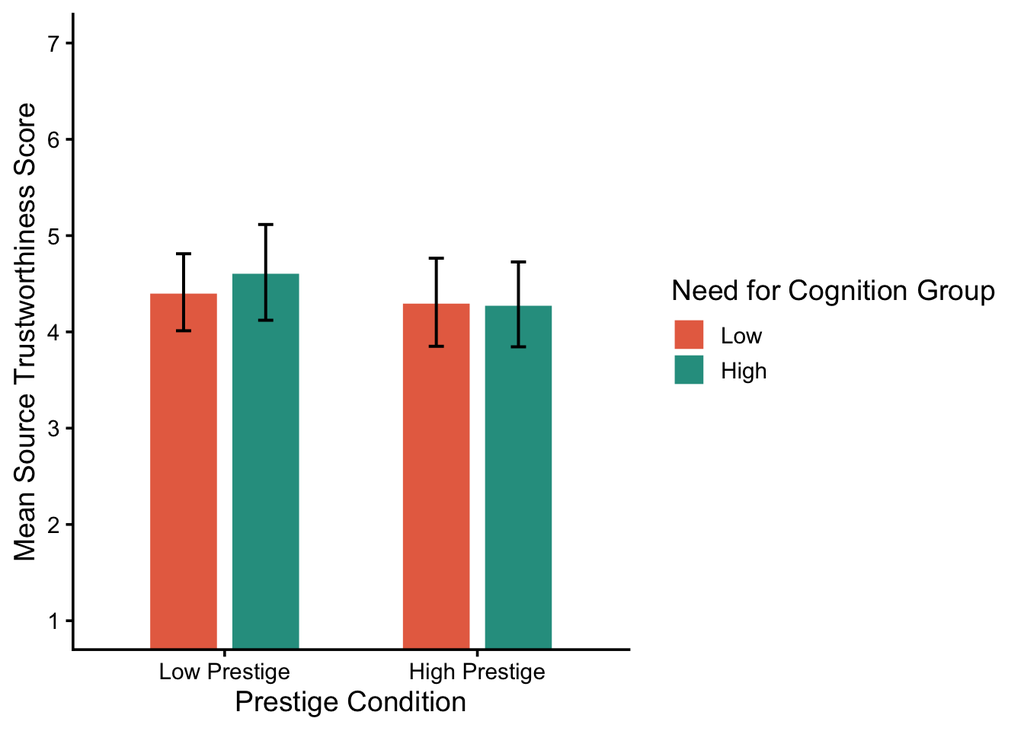

```r
p_source_trustworthiness_nfc_bar <- ggplot(
  as.data.frame(emmeans(a5_trustworthiness, ~ condition * nfc_msplit)),
  aes(
    x = condition,
    y = emmean,
    fill = nfc_msplit
  )
) +
  geom_col(
    position = position_dodge(width = 0.65),
    width = 0.55,
    color = "white"
  ) +
  geom_errorbar(
    aes(
      ymin = lower.CL,
      ymax = upper.CL
    ),
    position = position_dodge(width = 0.65),
    width = 0.12,
    linewidth = 0.7
  ) +
  labs(
    x = "Prestige Condition",
    y = "Mean Source Trustworthiness Score",
    fill = "Need for Cognition Group"
  ) +
  scale_fill_manual(
    values = c(
      "Low" = "#E76F51",
      "High" = "#2A9D8F"
    )
  ) +
  scale_y_continuous(
    breaks = seq(1, 7, 1)
  ) +
  coord_cartesian(
    ylim = c(1, 7)
  ) +
  theme_classic(
    base_size = 14
  )

p_source_trustworthiness_nfc_bar
```

The figure shows estimated Source Trustworthiness scores by Source Prestige condition and Need for Cognition group. Error bars represent 95% confidence intervals.

### Source Trustworthiness × Trust in Science Interaction Plot

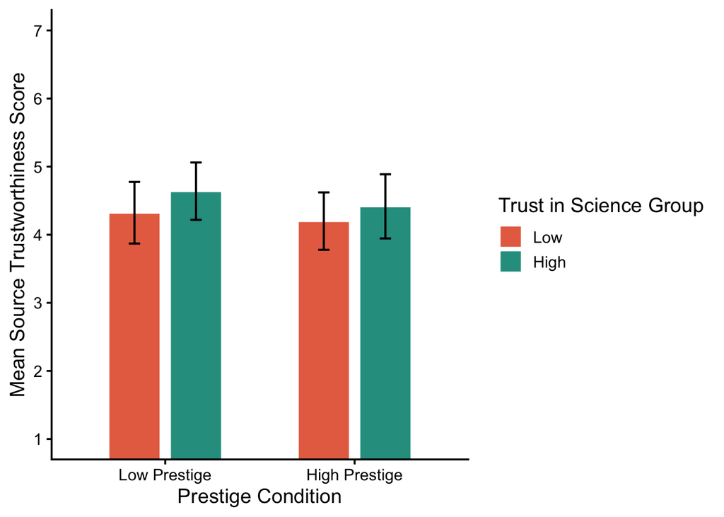

```r
p_source_trustworthiness_tis_bar <- ggplot(
  as.data.frame(emmeans(a6_trustworthiness, ~ condition * tis_msplit)),
  aes(
    x = condition,
    y = emmean,
    fill = tis_msplit
  )
) +
  geom_col(
    position = position_dodge(width = 0.65),
    width = 0.55,
    color = "white"
  ) +
  geom_errorbar(
    aes(
      ymin = lower.CL,
      ymax = upper.CL
    ),
    position = position_dodge(width = 0.65),
    width = 0.12,
    linewidth = 0.7
  ) +
  labs(
    x = "Prestige Condition",
    y = "Mean Source Trustworthiness Score",
    fill = "Trust in Science Group"
  ) +
  scale_fill_manual(
    values = c(
      "Low" = "#E76F51",
      "High" = "#2A9D8F"
    )
  ) +
  scale_y_continuous(
    breaks = seq(1, 7, 1)
  ) +
  coord_cartesian(
    ylim = c(1, 7)
  ) +
  theme_classic(
    base_size = 14
  )

p_source_trustworthiness_tis_bar
```

The figure shows estimated Source Trustworthiness scores by Source Prestige condition and Trust in Science and Scientists group. Error bars represent 95% confidence intervals.

### Export Figures

```r
if (!dir.exists("figures")) {
  dir.create("figures")
}

ggsave(
  filename = "figures/source_competence_nfc_interaction_plot.svg",
  plot = p_source_competence_nfc_bar,
  width = 7,
  height = 5
)

ggsave(
  filename = "figures/source_competence_tis_interaction_plot.svg",
  plot = p_source_competence_tis_bar,
  width = 7,
  height = 5
)

ggsave(
  filename = "figures/source_goodwill_nfc_interaction_plot.svg",
  plot = p_source_goodwill_nfc_bar,
  width = 7,
  height = 5
)

ggsave(
  filename = "figures/source_goodwill_tis_interaction_plot.svg",
  plot = p_source_goodwill_tis_bar,
  width = 7,
  height = 5
)

ggsave(
  filename = "figures/source_trustworthiness_nfc_interaction_plot.svg",
  plot = p_source_trustworthiness_nfc_bar,
  width = 7,
  height = 5
)

ggsave(
  filename = "figures/source_trustworthiness_tis_interaction_plot.svg",
  plot = p_source_trustworthiness_tis_bar,
  width = 7,
  height = 5
)
```

The figures were exported to the figures/ folder so they can be used in manuscript, poster, or repository materials.

## Results Summary

The primary analyses tested whether Source Prestige, Need for Cognition (NFC), Trust in Science and Scientists (TIS), and their interactions influenced perceptions of source competence, source goodwill, and source trustworthiness. Across all ANOVA models, neither Source Prestige nor the moderator variables significantly predicted ratings of source credibility.

In addition, no significant interactions were observed between Source Prestige and either Need for Cognition or Trust in Science and Scientists for any of the three credibility dimensions. Overall, participants reported similar perceptions of source competence, goodwill, and trustworthiness regardless of prestige condition, Need for Cognition group, or Trust in Science and Scientists group. The estimated means and interaction plots above illustrate the overall pattern of results for each outcome.